# Machine Learning 2019: Feature Selection

Sonali Narang

October 24, 2019

## Feature Selection

In machine learning, feature selection is the process of choosing variables that are useful in predicting the response variable. Selecting the right features in your data can mean the difference between mediocre performance with long training times and great performance with short training times that are less computationally intensive.

Often, data can contain attributes that are highly correlated with each other or not useful in helping predict our response variable. Many methods perform better if such variables are removed. Feature selection is usually imporant to implement during the data pre-processing steps of machine learning.

## The Breast Cancer Dataset

699 Observations, 11 variables/attributes/features Predictor Variable: Class- benign or malignant

```r
data(BreastCancer)
head(BreastCancer)
```

|  | Id | Cl.thickness | Cell.size | Cell.shape | Marg.adhesion | Epith.c.size | Bare.nuclei | Bl.cromatin | Normal.nucleoli | Mitoses | Class |
| --- | --- | --- | --- | --- | --- | --- | --- | --- | --- | --- | --- |
| 1 | 1000025 | 5 | 1 | 1 | 1 | 2 | 1 | 3 | 1 | 1 | benign |
| 2 | 1002945 | 5 | 4 | 4 | 5 | 7 | 10 | 3 | 2 | 1 | benign |
| 3 | 1015425 | 3 | 1 | 1 | 1 | 2 | 2 | 3 | 1 | 1 | benign |
| 4 | 1016277 | 6 | 8 | 8 | 1 | 3 | 4 | 3 | 7 | 1 | benign |
| 5 | 1017023 | 4 | 1 | 1 | 3 | 2 | 1 | 3 | 1 | 1 | benign |
| 6 | 1017122 | 8 | 10 | 10 | 8 | 7 | 10 | 9 | 7 | 1 | malignant |

```r
dim(BreastCancer)
```

```
## [1] 699  11
```

```r
summary(BreastCancer$Class)
```

```
##    benign malignant
##       458       241
```

## Feature Selection Using Filter Methods: Pearson’s Correlation

Filter Methods are generally used as a preprocessing step so the selection of features is independednt of any machine learning algorithms. Features are selected on the basis of their scores in various statistical tests for their correlation with the outcome variable.

Below we will identify attributes that are highly correlated using Pearson’s correlation which is a measure for quantifying linear dependence between X and Y. Ranges between -1 and 1.

Preprocessing set

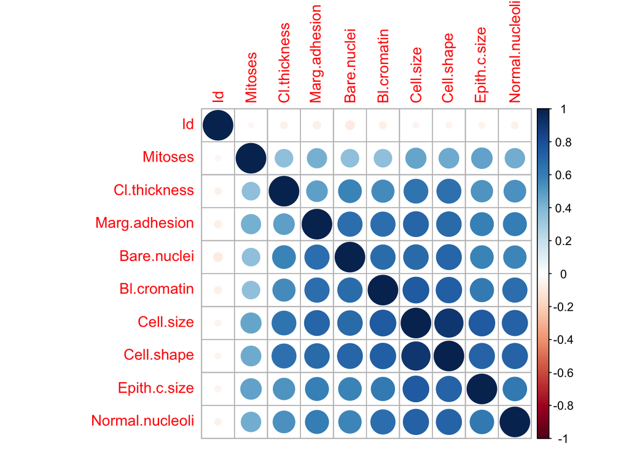

```r
BreastCancer_num = transform(BreastCancer, Id = as.numeric(Id),
                         Cl.thickness = as.numeric(Cl.thickness),
                         Cell.size = as.numeric(Cell.size),
                         Cell.shape = as.numeric(Cell.shape),
                         Marg.adhesion = as.numeric(Marg.adhesion),
                         Epith.c.size = as.numeric(Epith.c.size),
                         Bare.nuclei = as.numeric(Bare.nuclei),
                         Bl.cromatin = as.numeric(Bl.cromatin),
                         Normal.nucleoli = as.numeric(Normal.nucleoli),
                         Mitoses = as.numeric(Mitoses))

BreastCancer_num[is.na(BreastCancer_num)] = 0

#calculate correlation matrix using pearson correlation (others include spearman and kendall)
correlation_matrix = cor(BreastCancer_num[,1:10])

#visualize correlation matrix
library(corrplot)
corrplot(correlation_matrix, order = "hclust")
```

```r
#apply correlation filter of 0.7
highly_correlated <- colnames(BreastCancer[, -1])[findCorrelation(correlation_matrix, cutoff = 0.7, verbose = TRUE)]
```

```
## Compare row 3  and column  4 with corr  0.907
##   Means:  0.631 vs 0.477 so flagging column 3
## Compare row 4  and column  8 with corr  0.736
##   Means:  0.588 vs 0.447 so flagging column 4
## All correlations <= 0.7
```

```r
#which features are highly correlated and can be removed; you want to remove those which are highly correlated
highly_correlated
```

```
## [1] "Cell.shape"    "Marg.adhesion"
```

## Feature Selection Using Wrapper Methods: Recursive Feature Elimination (RFE)

Wrapper methods are a bit more computationally intensive since we will select features based on a specific machine learning algorith.

The RFE function implements backwards selection of predictors based on predictor importance ranking. The predictors are ranked and the less important ones are sequentially eliminated prior to modeling. The goal is to find a subset of predictors that can be used to produce an accurate model.

```r
data(BreastCancer)
BreastCancer_num = transform(BreastCancer, Id = as.numeric(Id),
                         Cl.thickness = as.numeric(Cl.thickness),
                         Cell.size = as.numeric(Cell.size),
                         Cell.shape = as.numeric(Cell.shape),
                         Marg.adhesion = as.numeric(Marg.adhesion),
                         Epith.c.size = as.numeric(Epith.c.size),
                         Bare.nuclei = as.numeric(Bare.nuclei),
                         Bl.cromatin = as.numeric(Bl.cromatin),
                         Normal.nucleoli = as.numeric(Normal.nucleoli),
                         Mitoses = as.numeric(Mitoses))

BreastCancer_num[is.na(BreastCancer_num)] = 0

#define the control
control = rfeControl(functions = caretFuncs, number = 2)

# run the RFE algorithm
results = rfe(BreastCancer_num[,1:10], BreastCancer_num[,11], sizes = c(2,5,9), rfeControl = control, method = "svmRadial")

results
```

```
##
## Recursive feature selection
##
## Outer resampling method: Bootstrapped (2 reps)
##
## Resampling performance over subset size:
##
##  Variables Accuracy  Kappa AccuracySD KappaSD Selected
##          2   0.9407 0.8619   0.015972 0.04154
##          5   0.9506 0.8851   0.013310 0.03265
##          9   0.9604 0.9093   0.005047 0.01183        *
##         10   0.9525 0.8917   0.010537 0.02331
##
## The top 5 variables (out of 9):
##    Cell.shape, Cell.size, Bl.cromatin, Bare.nuclei, Cl.thickness
```

```r
results$variables
```

| benign | malignant | Overall | var | Variables | Resample |
| --- | --- | --- | --- | --- | --- |
| 0.9672289 | 0.9672289 | 0.9672289 | Cell.shape | 10 | Resample1 |
| 0.9650333 | 0.9650333 | 0.9650333 | Cell.size | 10 | Resample1 |
| 0.9425526 | 0.9425526 | 0.9425526 | Bl.cromatin | 10 | Resample1 |
| 0.9368519 | 0.9368519 | 0.9368519 | Bare.nuclei | 10 | Resample1 |
| 0.9158834 | 0.9158834 | 0.9158834 | Cl.thickness | 10 | Resample1 |
| 0.9121887 | 0.9121887 | 0.9121887 | Epith.c.size | 10 | Resample1 |
| 0.8893817 | 0.8893817 | 0.8893817 | Marg.adhesion | 10 | Resample1 |
| 0.8737170 | 0.8737170 | 0.8737170 | Normal.nucleoli | 10 | Resample1 |
| 0.6872355 | 0.6872355 | 0.6872355 | Mitoses | 10 | Resample1 |
| 0.5639197 | 0.5639197 | 0.5639197 | Id | 10 | Resample1 |

[output cut: 42 more lines]

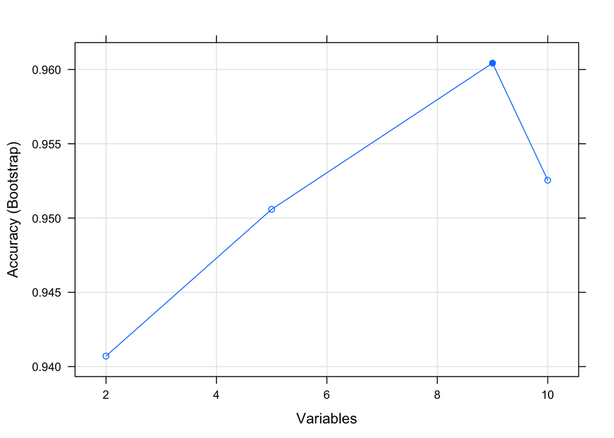

```r
plot(results, type =c("g","o"))
```

```r
predictors(results)
```

```
## [1] "Cell.shape"      "Cell.size"       "Bl.cromatin"     "Bare.nuclei"
## [5] "Cl.thickness"    "Epith.c.size"    "Marg.adhesion"   "Normal.nucleoli"
## [9] "Mitoses"
```

## Feature Selection Using Embedded Methods: Lasso

Least Absolute Shrinkage and Selection Operator (LASSO) regression

embedded method

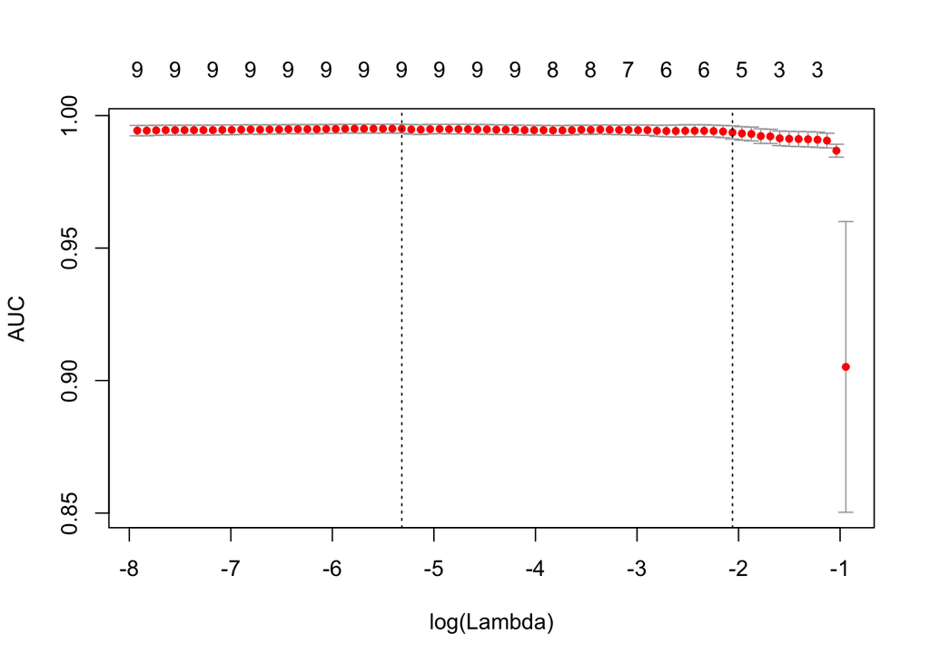

```r
set.seed(24)

#convert data
x <- as.matrix(BreastCancer_num[,1:10])
y = as.double(as.matrix(ifelse(BreastCancer_num[,11]=='benign', 0, 1)))

#fit Lasso model
cv.lasso <- cv.glmnet(x, y, family='binomial', alpha=1, parallel=TRUE, standardize=TRUE, type.measure='auc')

plot(cv.lasso)
```

```r
cat('Min Lambda: ', cv.lasso$lambda.min, '\n 1Sd Lambda: ', cv.lasso$lambda.1se)
```

```
## Min Lambda:  0.0049116
##  1Sd Lambda:  0.1274572
```

```r
df_coef <- round(as.matrix(coef(cv.lasso, s=cv.lasso$lambda.min)), 2)

# See all contributing variables
df_coef[df_coef[, 1] != 0, ]
```

```
##     (Intercept)    Cl.thickness       Cell.size      Cell.shape
##           -7.97            0.44            0.06            0.28
##   Marg.adhesion    Epith.c.size     Bare.nuclei     Bl.cromatin
##            0.16            0.05            0.37            0.33
## Normal.nucleoli         Mitoses
##            0.14            0.23
```

## Feature Selection Using Embedded Methods: RandomForest

Random Forest Importance function and caret package’s varImp functions perform similarly.

importance function used for tree based models

```r
#data
data(BreastCancer)
train_size <- floor(0.75 * nrow(BreastCancer))
set.seed(24)
train_pos <- sample(seq_len(nrow(BreastCancer)), size = train_size)

#convert to numeric
BreastCancer_num = transform(BreastCancer, Id = as.numeric(Id),
                         Cl.thickness = as.numeric(Cl.thickness),
                         Cell.size = as.numeric(Cell.size),
                         Cell.shape = as.numeric(Cell.shape),
                         Marg.adhesion = as.numeric(Marg.adhesion),
                         Epith.c.size = as.numeric(Epith.c.size),
                         Bare.nuclei = as.numeric(Bare.nuclei),
                         Bl.cromatin = as.numeric(Bl.cromatin),
                         Normal.nucleoli = as.numeric(Normal.nucleoli),
                         Mitoses = as.numeric(Mitoses))

BreastCancer_num[is.na(BreastCancer_num)] = 0

train_classification <- BreastCancer_num[train_pos, ]
test_classification <- BreastCancer_num[-train_pos, ]

#fit a model
rfmodel = randomForest(Class ~ Id + Cl.thickness + Cell.size + Cell.shape + Marg.adhesion + Epith.c.size + Bare.nuclei + Bl.cromatin + Normal.nucleoli +  Mitoses, data=train_classification,  importance = TRUE, oob.times = 15, confusion = TRUE)

#rank features based on importance
importance(rfmodel)
```

```
##                     benign malignant MeanDecreaseAccuracy MeanDecreaseGini
## Id              -0.6895607  6.306423             5.356937         4.753537
## Cl.thickness    20.1614358 21.864276            24.672793        15.817233
## Cell.size       13.2922349 16.005349            20.854493        51.850109
## Cell.shape       9.9205845 15.663444            18.547503        52.135873
## Marg.adhesion    6.9732478  8.757817            11.298839         7.495039
## Epith.c.size     8.2669770  3.558679             8.988390        14.948179
## Bare.nuclei     18.7963652 27.340734            28.123604        42.322414
## Bl.cromatin      8.5784618 14.394368            16.261622        28.772624
## Normal.nucleoli 11.9915409  9.888276            14.484327        19.497268
## Mitoses          6.3442746  2.271364             6.768548         1.615123
```

## Homework

1. Compare the most important features from at least 2 different classes of feature selection methods covered in this tutorial with any reasonable machine learning dataset from mlbench. Do these feature selection methods provide similar results?

```r
library(mlbench)
library(dplyr)
library(olsrr)
library(glmnet)
data <- PimaIndiansDiabetes %>%
  transform(data, pregnant <- as.numeric(pregnant),
            glucose <- as.numeric(glucose),
            pressure <- as.numeric(pressure),
            triceps <- as.numeric(triceps),
            insulin <- as.numeric(insulin),
            mass <- as.numeric(mass),
            pedigree <- as.numeric(pedigree),
            age <- as.numeric(age))
```

Filter Method: Pearson’s Correlation:

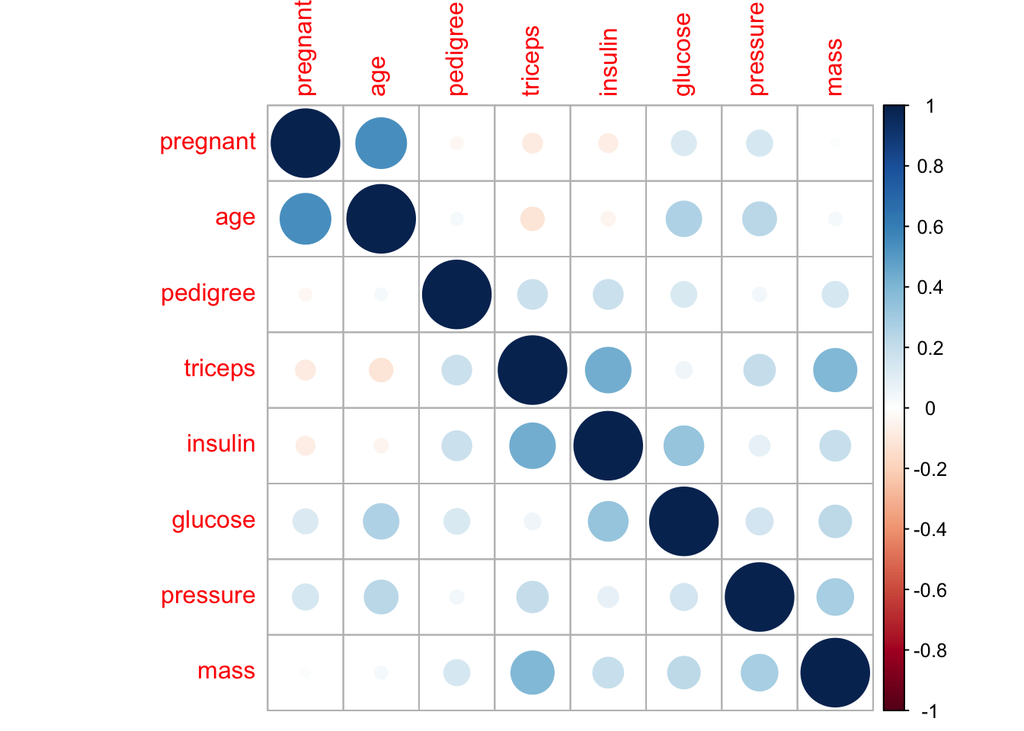

```r
#View(data)
data[is.na(data)] = 0
cormatrix = cor(data[,1:8])
library(corrplot)
corrplot(cormatrix, order = "hclust")
```

```r
highlycorrelated <- colnames(data[, -9])[findCorrelation(correlation_matrix, cutoff = 0.7, verbose = TRUE)]
```

```
## Compare row 3  and column  4 with corr  0.907
##   Means:  0.631 vs 0.477 so flagging column 3
## Compare row 4  and column  8 with corr  0.736
##   Means:  0.588 vs 0.447 so flagging column 4
## All correlations <= 0.7
```

```r
highlycorrelated
```

```
## [1] "pressure" "triceps"
```

```r
colnames(data)
```

```
## [1] "pregnant" "glucose"  "pressure" "triceps"  "insulin"  "mass"
## [7] "pedigree" "age"      "diabetes"
```

Lasso Regression

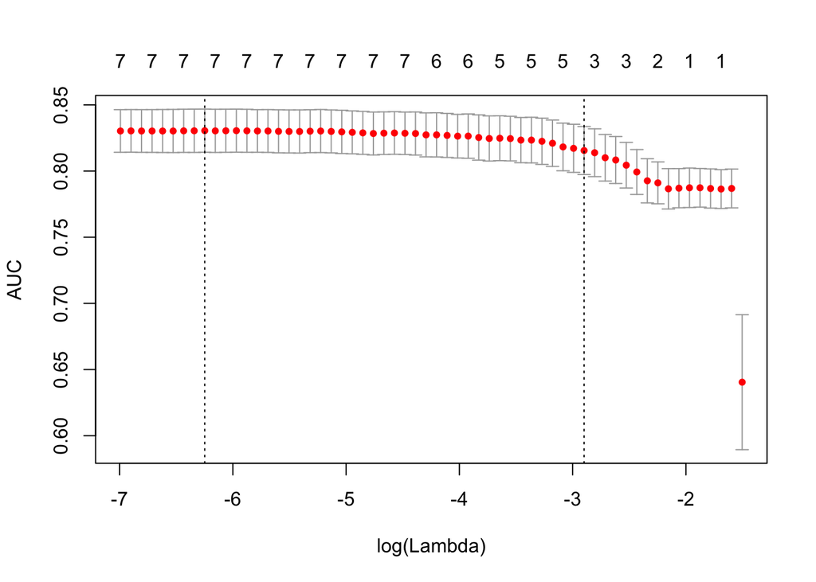

```r
set.seed(124)
data[is.na(data)] = 0

x.dat <- as.matrix(data[,1:8])
y.dat = as.double(as.matrix(ifelse(data[,9]=='neg', 0, 1)))

cvlasso <- cv.glmnet(x.dat, y.dat, family='binomial', alpha=1, parallel=TRUE, standardize=TRUE, type.measure='auc')

plot(cvlasso)
```

```r
cat('Min Lambda: ', cvlasso$lambda.min, '\n 1Sd Lambda: ', cvlasso$lambda.1se)
```

```
## Min Lambda:  0.00193425
##  1Sd Lambda:  0.05508813
```

```r
dfcoef <- round(as.matrix(coef(cvlasso, s=cvlasso$lambda.min)), 2)

dfcoef[dfcoef[, 1] != 0, ]
```

```
## (Intercept)    pregnant     glucose    pressure        mass    pedigree
##       -8.21        0.12        0.03       -0.01        0.09        0.89
##         age
##        0.01
```

2. Attempt a feature selection method not covered in this tutorial (backward elimination, forward propogation, etc.)

Backwards Elimination

```r
model <- lm( pregnant~ ., data = data)
ols_step_backward_p(model)
```

```
## Backward Elimination Method
## ---------------------------
##
## Candidate Terms:
##
## 1 . glucose
## 2 . pressure
## 3 . triceps
## 4 . insulin
## 5 . mass
## 6 . pedigree
## 7 . age
## 8 . diabetes
##
## We are eliminating variables based on p value...
##
## Variables Removed:
##
## ✖ triceps
## ✖ mass
## ✖ pressure
##
## No more variables satisfy the condition of p value = 0.3
##
##
## Final Model Output
## ------------------
##
##                         Model Summary
## --------------------------------------------------------------
## R                       0.561       RMSE                2.798
## R-Squared               0.315       Coef. Var          72.780
## Adj. R-Squared          0.310       MSE                 7.831
## Pred R-Squared          0.302       MAE                 2.114
## --------------------------------------------------------------
##  RMSE: Root Mean Square Error
##  MSE: Mean Square Error
##  MAE: Mean Absolute Error
##
##                                 ANOVA
## ---------------------------------------------------------------------
##                 Sum of
##                Squares         DF    Mean Square      F         Sig.
## ---------------------------------------------------------------------
## Regression    2741.123          5        548.225    70.004    0.0000
## Residual      5967.438        762          7.831
## Total         8708.561        767
## ---------------------------------------------------------------------
##
##                                   Parameter Estimates
## ---------------------------------------------------------------------------------------
##       model      Beta    Std. Error    Std. Beta      t        Sig      lower    upper
## ---------------------------------------------------------------------------------------
## (Intercept)    -0.466         0.479                 -0.973    0.331    -1.406    0.474
##     glucose    -0.005         0.004       -0.051    -1.387    0.166    -0.013    0.002
##     insulin    -0.001         0.001       -0.041    -1.269    0.205    -0.003    0.001
##    pedigree    -0.613         0.314       -0.060    -1.951    0.051    -1.229    0.004
##         age     0.151         0.009        0.526    16.585    0.000     0.133    0.168
## diabetespos     0.961         0.244        0.136     3.943    0.000     0.483    1.440
## ---------------------------------------------------------------------------------------
```

```
##
##
##                            Elimination Summary
## -------------------------------------------------------------------------
##         Variable                  Adj.
## Step    Removed     R-Square    R-Square     C(p)        AIC        RMSE
## -------------------------------------------------------------------------
##    1    triceps       0.3157      0.3093    7.0031    3771.1107    2.8003
##    2    mass          0.3152      0.3098    5.4899    3769.6030    2.7994
##    3    pressure      0.3148      0.3103    3.9885    3768.1072    2.7984
## -------------------------------------------------------------------------
```

[output not shown]

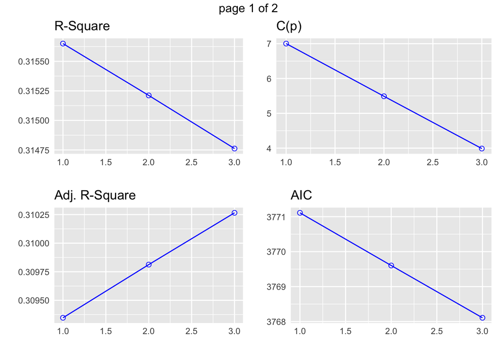

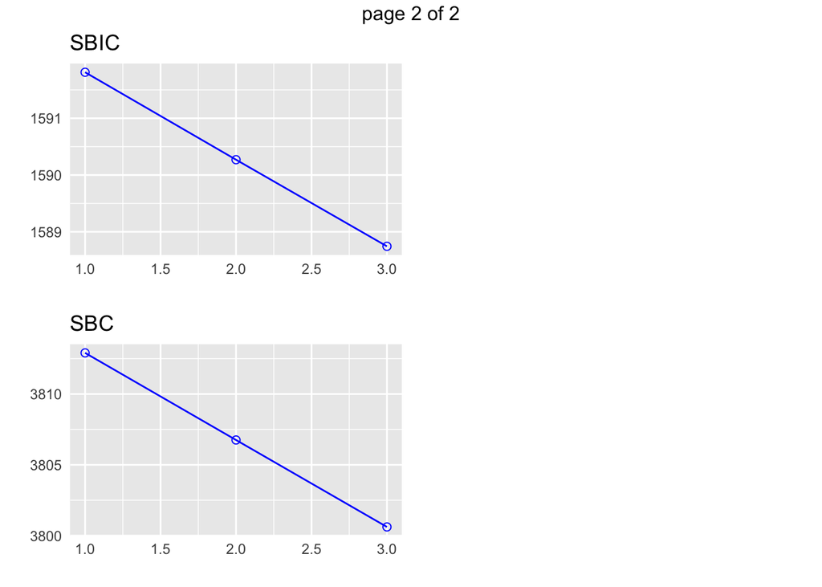

```r
plot(ols_step_backward_p(model))
```

```r
ols_step_backward_p(model, details = T)
```

```
## Backward Elimination Method
## ---------------------------
##
## Candidate Terms:
##
## 1 . glucose
## 2 . pressure
## 3 . triceps
## 4 . insulin
## 5 . mass
## 6 . pedigree
## 7 . age
## 8 . diabetes
##
## We are eliminating variables based on p value...
##
## ✖ triceps
##
## Backward Elimination: Step 1
##
##  Variable triceps Removed
##
##                         Model Summary
## --------------------------------------------------------------
## R                       0.562       RMSE                2.800
## R-Squared               0.316       Coef. Var          72.829
## Adj. R-Squared          0.309       MSE                 7.842
## Pred R-Squared          0.298       MAE                 2.112
## --------------------------------------------------------------
##  RMSE: Root Mean Square Error
##  MSE: Mean Square Error
##  MAE: Mean Absolute Error
##
##                                 ANOVA
## ---------------------------------------------------------------------
##                 Sum of
##                Squares         DF    Mean Square      F         Sig.
## ---------------------------------------------------------------------
## Regression    2748.860          7        392.694    50.078    0.0000
## Residual      5959.701        760          7.842
```

[output cut: 130 more lines]

```
## Residual      5967.438        762          7.831
## Total         8708.561        767
## ---------------------------------------------------------------------
##
##                                   Parameter Estimates
## ---------------------------------------------------------------------------------------
##       model      Beta    Std. Error    Std. Beta      t        Sig      lower    upper
## ---------------------------------------------------------------------------------------
## (Intercept)    -0.466         0.479                 -0.973    0.331    -1.406    0.474
##     glucose    -0.005         0.004       -0.051    -1.387    0.166    -0.013    0.002
##     insulin    -0.001         0.001       -0.041    -1.269    0.205    -0.003    0.001
##    pedigree    -0.613         0.314       -0.060    -1.951    0.051    -1.229    0.004
##         age     0.151         0.009        0.526    16.585    0.000     0.133    0.168
## diabetespos     0.961         0.244        0.136     3.943    0.000     0.483    1.440
## ---------------------------------------------------------------------------------------
```

```
##
##
##                            Elimination Summary
## -------------------------------------------------------------------------
##         Variable                  Adj.
## Step    Removed     R-Square    R-Square     C(p)        AIC        RMSE
## -------------------------------------------------------------------------
##    1    triceps       0.3157      0.3093    7.0031    3771.1107    2.8003
##    2    mass          0.3152      0.3098    5.4899    3769.6030    2.7994
##    3    pressure      0.3148      0.3103    3.9885    3768.1072    2.7984
## -------------------------------------------------------------------------
```

```r
#or

step(object = model, direction = "backward")
```

```
## Start:  AIC=1591.62
## pregnant ~ glucose + pressure + triceps + insulin + mass + pedigree +
##     age + diabetes
##
##            Df Sum of Sq    RSS    AIC
## - triceps   1      0.02 5959.7 1589.6
## - mass      1      3.63 5963.3 1590.1
## - pressure  1      5.72 5965.4 1590.4
## - insulin   1     10.29 5970.0 1590.9
## - glucose   1     15.00 5974.7 1591.5
## <none>                  5959.7 1591.6
## - pedigree  1     28.45 5988.1 1593.3
## - diabetes  1    126.51 6086.2 1605.8
## - age       1   1947.77 7907.4 1806.8
##
## Step:  AIC=1589.62
## pregnant ~ glucose + pressure + insulin + mass + pedigree + age +
##     diabetes
##
##            Df Sum of Sq    RSS    AIC
## - mass      1      3.82 5963.5 1588.1
## - pressure  1      5.97 5965.7 1588.4
## - insulin   1     11.81 5971.5 1589.1
## - glucose   1     15.50 5975.2 1589.6
## <none>                  5959.7 1589.6
## - pedigree  1     28.57 5988.3 1591.3
## - diabetes  1    126.54 6086.2 1603.8
## - age       1   1973.69 7933.4 1807.3
##
## Step:  AIC=1588.11
## pregnant ~ glucose + pressure + insulin + pedigree + age + diabetes
##
##            Df Sum of Sq    RSS    AIC
## - pressure  1      3.92 5967.4 1586.6
## - insulin   1     13.55 5977.1 1587.9
## <none>                  5963.5 1588.1
## - glucose   1     16.12 5979.6 1588.2
## - pedigree  1     30.13 5993.6 1590.0
## - diabetes  1    123.25 6086.8 1601.8
## - age       1   2010.64 7974.2 1809.2
##
## Step:  AIC=1586.62
## pregnant ~ glucose + insulin + pedigree + age + diabetes
##
##            Df Sum of Sq    RSS    AIC
## - insulin   1     12.61 5980.0 1586.2
## - glucose   1     15.07 5982.5 1586.5
## <none>                  5967.4 1586.6
## - pedigree  1     29.79 5997.2 1588.4
## - diabetes  1    121.78 6089.2 1600.1
## - age       1   2154.18 8121.6 1821.3
##
## Step:  AIC=1586.24
## pregnant ~ glucose + pedigree + age + diabetes
##
##            Df Sum of Sq    RSS    AIC
## <none>                  5980.0 1586.2
## - glucose   1     28.18 6008.2 1587.8
## - pedigree  1     36.88 6016.9 1589.0
## - diabetes  1    124.20 6104.3 1600.0
## - age       1   2242.90 8223.0 1828.8
```

```
##
## Call:
## lm(formula = pregnant ~ glucose + pedigree + age + diabetes,
##     data = data)
##
## Coefficients:
## (Intercept)      glucose     pedigree          age  diabetespos
##   -0.399467    -0.006902    -0.673607     0.152165     0.970602
```